# Urbana Traffic Stops

Evelyn Cai

6/30/2020

## Exploratory Data Analysis

```r
skim(tstopoffenses)
```

[output not shown]

After runnning skim(), I wanted to explore why some values were missing. Some were obvious: `drug_amount_found_canine_search` was probably NA if a canine search was not involved. Others seem to be less logically missing, such as `motivation_for_stop_desc`, which has a lower complete rate compared to other variables. After exploring the data, I noticed that motivations were generally not reported before 4/30/2015.

To work with the total number of traffic stops, rather than traffic stop offenses, we have to do some reshaping of the data.

Upon fiddling with the data more, here’s what I hope to put together by the end of the project: * Interaction plots and parallel slopes models for variables such as: disparity ratio, stops & resultant arrest %s, and % contraband found out of consent searches * Easily digestible plots that show: + Breakdown of interacting variables + Outcome likelihoods after being stopped compared to a baseline (either group average or being white/male) + Impact of location (?) and time of day on the stop

## Initial Analysis

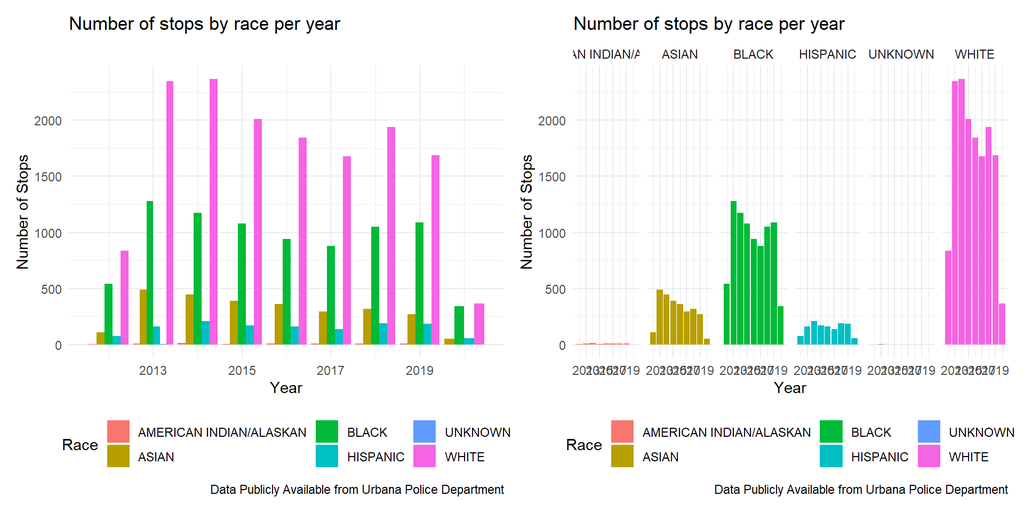

From the graphs above, you can see general trends in which traffic stops lowered by total volume around 2017, only to increase again in recent years.

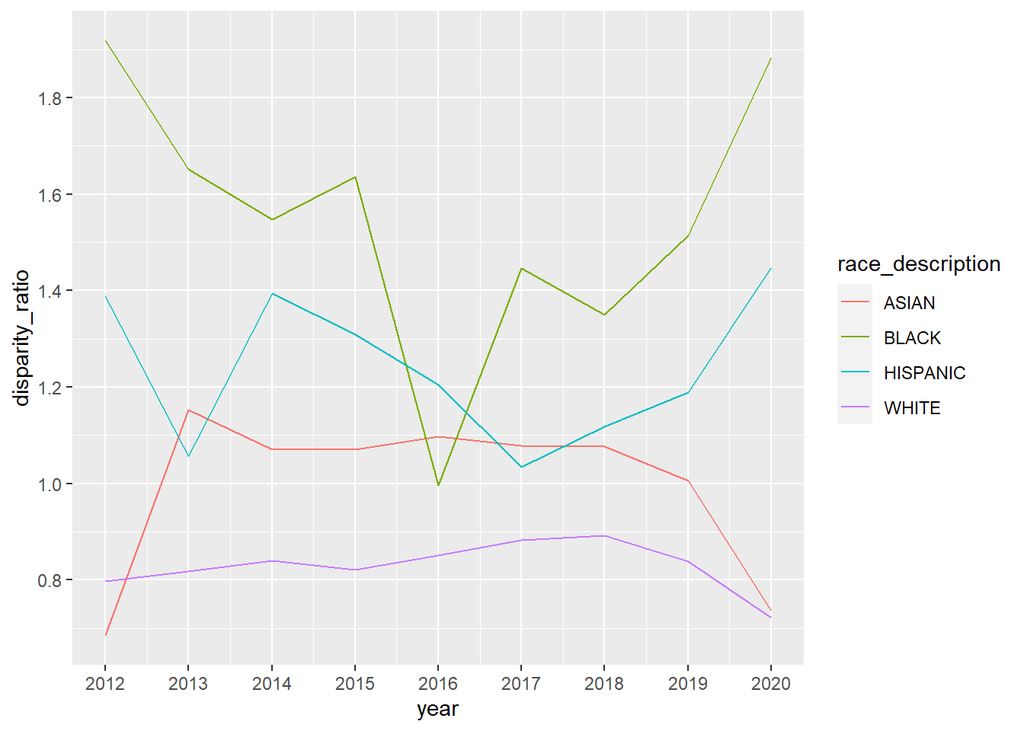

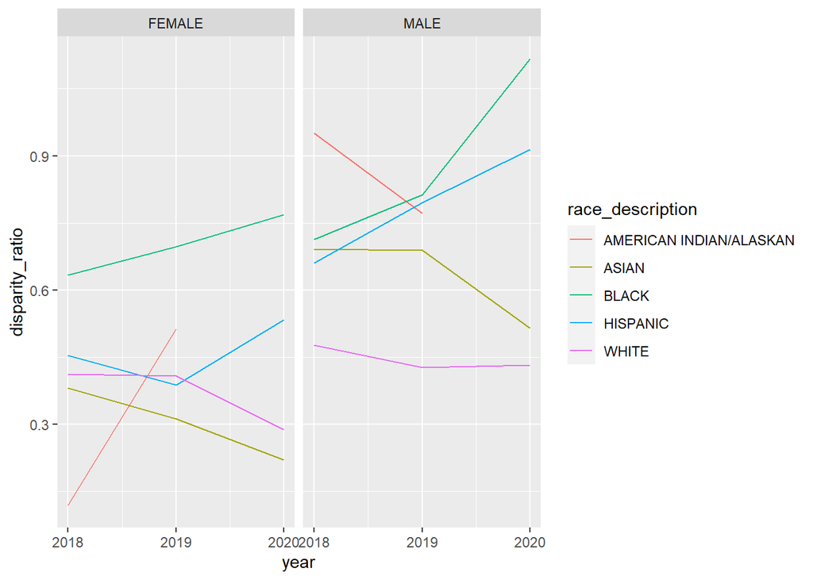

## Questions for Melissa

1. My numbers are slightly off, what could be the case? The biggest disparity is 2018, everything else is 1 or 2 stops off